# Session6_ML_Sample

## Train/Test Split

In Supervised ML we usually split data into 2 subsets: train and test data. We fit/train a model on train and make predictions on the test dataset. We then evaluate the prediction performance.

- The training set contains a known output, where the model learns on this data to be able to generalized to other data later on.
- The test dataset (or subset) is used to test our model’s prediction on this subset

We’ll do this using the Scikit-Learn library and specifically the train_test_split methods.

**Linear Regression Example using diabetes dataset**

Reference

- https://scikit-learn.org/stable/modules/generated/sklearn.linear_model.LinearRegression.html

```python
# load required libraries
import pandas as pd
from sklearn import datasets
from sklearn.linear_model import LinearRegression
from sklearn.model_selection import train_test_split
from matplotlib import pyplot as plt
```

**load in the diabetes dataset, turn it into a data frame and define the columns**

```python
columns = 'age sex bmi map tc ldl hdl tch ltg glu'.split()

# load the dataset from sklearn and create a pandas data frame
diabetes = datasets.load_diabetes()
df = pd.DataFrame(diabetes.data, columns=columns)
```

```python
# show the dataset description
print(diabetes['DESCR'])
```

```
.. _diabetes_dataset:

Diabetes dataset
----------------

Ten baseline variables, age, sex, body mass index, average blood
pressure, and six blood serum measurements were obtained for each of n =
442 diabetes patients, as well as the response of interest, a
quantitative measure of disease progression one year after baseline.

**Data Set Characteristics:**

  :Number of Instances: 442

  :Number of Attributes: First 10 columns are numeric predictive values

  :Target: Column 11 is a quantitative measure of disease progression one year after baseline

  :Attribute Information:
      - age     age in years
      - sex
      - bmi     body mass index
      - bp      average blood pressure
      - s1      tc, T-Cells (a type of white blood cells)
      - s2      ldl, low-density lipoproteins
      - s3      hdl, high-density lipoproteins
      - s4      tch, thyroid stimulating hormone
      - s5      ltg, lamotrigine
      - s6      glu, blood sugar level

Note: Each of these 10 feature variables have been mean centered and scaled by the standard deviation times `n_samples` (i.e. the sum of squares of each column totals 1).

Source URL:
https://www4.stat.ncsu.edu/~boos/var.select/diabetes.html

For more information see:
Bradley Efron, Trevor Hastie, Iain Johnstone and Robert Tibshirani (2004) "Least Angle Regression," Annals of Statistics (with discussion), 407-499.
(https://web.stanford.edu/~hastie/Papers/LARS/LeastAngle_2002.pdf)
```

**specify the features (x values) and target (y value)**

In this case all columns in the dataframe are x. There is a separate field for the targe

```python
# only the input features, y is the target/prediction and used as the label for regression
df.info()
```

```
<class 'pandas.core.frame.DataFrame'>
RangeIndex: 442 entries, 0 to 441
Data columns (total 10 columns):
 #   Column  Non-Null Count  Dtype
---  ------  --------------  -----
 0   age     442 non-null    float64
 1   sex     442 non-null    float64
 2   bmi     442 non-null    float64
 3   map     442 non-null    float64
 4   tc      442 non-null    float64
 5   ldl     442 non-null    float64
 6   hdl     442 non-null    float64
 7   tch     442 non-null    float64
 8   ltg     442 non-null    float64
 9   glu     442 non-null    float64
dtypes: float64(10)
memory usage: 34.7 KB
```

```python
df.head()
```

|  | age | sex | bmi | map | tc | ldl | hdl | tch | ltg | glu |
| --- | --- | --- | --- | --- | --- | --- | --- | --- | --- | --- |
| 0 | 0.038076 | 0.050680 | 0.061696 | 0.021872 | -0.044223 | -0.034821 | -0.043401 | -0.002592 | 0.019908 | -0.017646 |
| 1 | -0.001882 | -0.044642 | -0.051474 | -0.026328 | -0.008449 | -0.019163 | 0.074412 | -0.039493 | -0.068330 | -0.092204 |
| 2 | 0.085299 | 0.050680 | 0.044451 | -0.005671 | -0.045599 | -0.034194 | -0.032356 | -0.002592 | 0.002864 | -0.025930 |
| 3 | -0.089063 | -0.044642 | -0.011595 | -0.036656 | 0.012191 | 0.024991 | -0.036038 | 0.034309 | 0.022692 | -0.009362 |
| 4 | 0.005383 | -0.044642 | -0.036385 | 0.021872 | 0.003935 | 0.015596 | 0.008142 | -0.002592 | -0.031991 | -0.046641 |

```python
y = diabetes.target # define the target variable (dependent variable)
```

**use the train_test_split to make the split. It’s common to use train/test splits of 80/20 or 70/30**

```python
X_train, X_test, y_train, y_test = train_test_split(df, y, test_size=0.2) # 80/20 split

print (X_train.shape, y_train.shape, '\n',
       X_test.shape, y_test.shape)
```

```
(353, 10) (353,)
 (89, 10) (89,)
```

- Notice the shape of X_train, y_train (353 is 80% of the dataset) and X_test, y_test (89 is 20%)
- X_train includes inputs, y_train is just the label (these were used to train the algorithm/model)
- X_test includes inputs, y_test is just the label (these are used to test performance of the trained model)

**fit/train a linear regression model and make predictions**

```python
model = LinearRegression()  #linear regression model
model.fit(X_train, y_train) #fit/train the model to the training data

# make predictions on unseen test. data
predictions = model.predict(X_test)

# view the first 5 predictions
predictions[0:5]
```

```
array([ 85.41304617, 112.18025152, 101.53245902, 153.00166943,
       249.35168281])
```

- print accuracy. model accuracy score metric depends on the algorithm used
- for LinearRegression, this returns R2 (coefficient of determination of the prediction).

```python
print ('Score:', model.score(X_test, y_test))
```

```
Score: 0.5545652847434623
```

**Plot the model (true values vs predicted)**

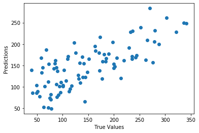

```python
plt.scatter(x=y_test, y=predictions)
plt.xlabel('True Values')
plt.ylabel('Predictions');
```

Train/test split method does have some limitations. — what if the split we make isn’t random?

- What if one subset of our data has only people from a certain state, employees with a certain income level but not other income levels, only women or only people at a certain age? This will result in overfitting.
- In order to avoid this, we can perform **cross validation**. (See discussion later)

## Overfitting vs Underfitting

- **Model Underfitting**: where a model can neither model the training data nor generalize to new data. An underfit ML model is obvious as it will have poor performance on the training data.
  - Underfitting is easy to detect given a good performance metric.
  - The solution is to try alternate ML algorithms
- **Model Overfitting** : where a model learns the noise in the training data as to negatively impact model performance on new data. The noise or random fluctuations in the training data is learned as concepts by the model, however these concepts do not apply to new data (eg: the model can't generalize to new/unseen data)
  - more likely with nonparametric and nonlinear models that have more flexibility when learning a target function
  - many nonparametric ML algorithms also include parameters or techniques to limit/constrain how much detail the model learns

Both impact the predictability of a model, but by far the most common problem is overfitting. An optimun model is one at the sweet spot between underfitting and overfitting, but this is difficult to do in practice.

We can look at the performance of a ML algorithm over time as it is learning on training data.

- We can plot both the performance on the training data and test dataset
- Over time, as the algorithm learns, the error for the model on the training goes down and so does the error on the test dataset
- If we train for too long, the performance on train may continue to decrease because the model is overfitting. At the same time the error for test starts to rise again as the model’s ability to generalize decreases
- The sweet spot is the point just before the error on the test dataset starts to increase, where the model has good skill on both the training dataset and the unseen test dataset

### There are 2 main techniques when evaluating ML algorithms to limit overfitting:

- **resampling to estimate model accuracy**: the most popular is **k-fold cross validation** which allows you to train and test a model (k-times) on different subsets of training data and build up an estimate of its performance on unseen data.
- **hold back/validation dataset**: a subset of your training data held back from your ML algorithms, used to evalaute model performance. After you have selected and *tuned* your ML algorithms on the training dataset, you can evaluate the learned model(s) on the validation dataset, to get an idea of how it might perform on unseen data.

One approach to limiting overfitting is by varying a key model **hyperparameter** and evaluating the model performance on the train/test sets for each configuration using k-fold validation

### Example: Overfitting Analysis

Use a **Decision Tree** via the DecisionTreeClassifier and test different tree depths with the “max_depth” argument.

- shallow trees (few levels) generally do not overfit but have poor performance (high bias, low variance).
- deep trees (many levels) generally do overfit and have good performance (low bias, high variance).
- a desirable tree is one that is neither so shallow that it has low skill and not so deep that it overfits the training dataset

```python
# import libraires
from sklearn.datasets import make_classification
from sklearn.model_selection import train_test_split
from sklearn.metrics import accuracy_score
from sklearn.tree import DecisionTreeClassifier
from matplotlib import pyplot
```

```python
# creaate a synthetic classification dataset with 10000 observations and 20 features/ columns
X, y = make_classification(n_samples=10000, n_features=20,
                           n_informative=5, n_redundant=15,
                           random_state=1) # for predicatable results between runs use the same random state

print(X.shape, y.shape)
```

```
(10000, 20) (10000,)
```

```python
# split data into 70% for training and 30% for test/evaluation
X_train, X_test, y_train, y_test = train_test_split(X, y, test_size=0.3) # 30% test, 70% train

print(X_train.shape, X_test.shape, '\n',
      y_train.shape, y_test.shape)
```

```
(7000, 20) (3000, 20)
 (7000,) (3000,)
```

```python
# lists to collect scores
train_scores, test_scores = list(), list()

# list to define the tree depths to evaluate
values = [i for i in range(1, 21)]

# evaluate a decision tree for each depth
for i in values:
    model = DecisionTreeClassifier(max_depth=i) # decision tree model

    model.fit(X_train, y_train)  # fit/train

    # evaluate on the train dataset
    train_yhat = model.predict(X_train)
    train_acc = accuracy_score(y_train, train_yhat)
    train_scores.append(train_acc)

    # evaluate on the test dataset
    test_yhat = model.predict(X_test)
    test_acc = accuracy_score(y_test, test_yhat)
    test_scores.append(test_acc)

    # summarize progress
    print(f'{i} train: {round(train_acc, 3)} test: { round(test_acc, 3)}')
```

```
1 train: 0.764 test: 0.774
2 train: 0.811 test: 0.801
3 train: 0.886 test: 0.873
4 train: 0.909 test: 0.893
5 train: 0.918 test: 0.899
6 train: 0.925 test: 0.904
7 train: 0.935 test: 0.907
8 train: 0.944 test: 0.911
9 train: 0.958 test: 0.922
10 train: 0.967 test: 0.92
11 train: 0.974 test: 0.918
12 train: 0.98 test: 0.915
13 train: 0.986 test: 0.915
14 train: 0.99 test: 0.916
15 train: 0.992 test: 0.917
16 train: 0.995 test: 0.92
17 train: 0.998 test: 0.92
18 train: 0.999 test: 0.914
19 train: 1.0 test: 0.915
20 train: 1.0 test: 0.916
```

Plot all model accuracy scores on the train and test datasets to visualize this. The plot shows that increasing tree depth in the early stages results in a corresponding improvement in both train and test sets, and continues until a depth of ~10 levels, after which the model overfits the training dataset at a cost of worse performance on the test/holdout dataset.

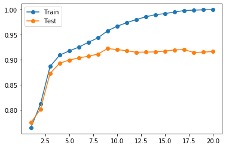

```python
pyplot.plot(values, train_scores, '-o', label='Train')
pyplot.plot(values, test_scores, '-o', label='Test')
pyplot.legend()
pyplot.show()
```

## k-Fold Cross-Validation

Cross validation is very similar to train/test split, but applied to more subsets. We split our data into k subsets, and train on k-1 one of those subset, while holdiing the last subset for test. There are various cross validation methods: K-Folds cross-validation, Leave One Out cross-validation. We will discuss k-fold.

The k-fold cross-validation procedure divides a limited dataset into k non-overlapping folds. Each of the k folds is given an opportunity to be used as a held back test set, while all other folds collectively are used as a training dataset. A total of k models are fit and evaluated on the k hold-out test sets and the mean performance is reported. A value of 5 or 10 folds is typical.

- **StratifiedKFold** takes the cross validation a step further, where the class distribution in the dataset is preserved in the training and test splits. Therefore, in classifications tasks with imbalanced class distributions, we should prefer StratifiedKFold over KFold
- **cross_val_score**: takes the dataset and applies cross validation to split the data. Then, train a model using the specified algorithm (e.g. logistic regression, decision tree, …) and measure the performance of the model (scoring parameter). The procedure is as follows:
  - The model is trained using K-1 of the folds as training data
  - The resulting model is validated on the remaining data
  - This process is repeated K times and performance measure such as "ACCURACY" is computed at each step.

**Example**  
Evaluate a LogisticRegression model and use the KFold class to perform the cross-validation, configured to shuffle the dataset and set k=10, a popular default.

```python
# evaluate a logistic regression model using k-fold cross-validation
from numpy import mean
from numpy import std
from sklearn.datasets import make_classification
from sklearn.model_selection import KFold
from sklearn.model_selection import cross_val_score
from sklearn.linear_model import LogisticRegression

# create synthetic dataset
X, y = make_classification(n_samples=1000, n_features=20,
                           n_informative=15, n_redundant=5,
                           random_state=1)

# prepare the cross-validation with 10 splits
kf = KFold(n_splits=10, random_state=1, shuffle=True)

# visulize the folds
for train_index, test_index in kf.split(X, y):
    print("TRAIN:", train_index, "\nTEST:", test_index)
```

[output not shown]

[output cut: 545 more lines]

```python
model = LogisticRegression() # create logistic regression model

# evaluate model
scores = cross_val_score(model, X, y, scoring='accuracy', cv=kf, n_jobs=-1)
print (scores)

# report performance
print(f"Accuracy:  mean = {round(mean(scores), 3)} , std = {round(std(scores), 3)}")
```

```
[0.89 0.82 0.92 0.88 0.91 0.82 0.86 0.86 0.85 0.87]
Accuracy:  mean = 0.868 , std = 0.032
```

**Using StratifiedKFold**

```python
from sklearn.model_selection import StratifiedKFold

X, y = make_classification(n_samples=1000, n_features=20,
                           n_informative=15, n_redundant=5,
                           random_state=1)

# prepare the cross-validation with 5 splits
kf = StratifiedKFold(n_splits=5, random_state=1, shuffle=True)
kf.split(X, y)

# evaluate model
scores = cross_val_score(model, X, y, scoring='accuracy', cv=kf, n_jobs=-1)
print (scores)

# report performance
print(f"Accuracy:  mean = {round(mean(scores), 3)} , std = {round(std(scores), 3)}")
```

```
[0.845 0.87  0.9   0.85  0.885]
Accuracy:  mean = 0.87 , std = 0.021
```

- In the validation approach (train/test/split), only a subset of the observations—those that are included in the training set rather than in the validation set—are used to fit the model. Since statistical methods tend to perform worse when trained on fewer observations, this suggests that the validation set error rate may tend to overestimate the test error rate for the model fit on the entire data set.
- Cross validation deals with this problem by using all the data available and thus eliminating the bias.
- However the amount of time for training is less using the train/test/split approach, therefore for computation constrains or large datasets, this may be preferable

## Machine Learning Algorithms

### Supervised machine learning

In supervised learning algorithms using known datasets (eg: training datasets) to make predictions. These algorithms learn the mapping function from input variables (x) to an output variable (y); eg: y = f(X). The objective is to approximate the mapping function (f) as accurately as possible such that whenever there is new input data (x), the output variable (y) for the dataset can be predicted.

Regression and classification are examples of supervised machine learning. Their main difference is that y in Regression is continuous (numerical) while for classification, it is categorical (or discrete).

**Regression algorithms** estimate the mapping function (f) from the input variables (x) to numerical or continuous output variables (y). For example, given a dataset about houses, a regression task is to predict housing prices where price is a continuous output. Examples of the common regression algorithms include

- linear regression
- Support Vector Regression (SVR) and regression trees.

**Classification in machine learning** estimate the mapping function (f) from the input variables (x) to discrete or categorical output variables (y). When provided with one or more input variables, a classification model attempts to predict the value of a single or several conclusions. For example: predicting whether prices for houses “sell more or less than the recommended retail price.” Here, houses are classified whether their prices fall into two discrete categories: "above" or "below" this price. Examples of the common classification algorithms include:

- logistic regression: predicting a binary outcome (eg: whether a tumor is cancerous or not)
- Naïve Bayes
- decision trees
- K-NN (k nearest neighbors)
- KMeans (note: an unsupervised ML algorithm)

### Unsupervised Machine Learning

Unsupervised models are used when the class label of each sample is not available. Unsupervised clustering methods such as k-means create groups with instances that have similarities. If one does not have the class labels associated with dataset, one can use clustering methods to help identy classes by finding out related instances. Then use supervised methods can be used to learn from new labeled data set. Examples of unsupervised algorithms:

- Hierarchical clustering
- K-means clustering
- Principal Component Analysis (for feature reduction)

### Multiple Linear Regression Model Example

Example Predicting Sales based on add expenditures

```python
import numpy as np
import pandas as pd

# linear regression model
from sklearn.linear_model import LinearRegression
from sklearn.model_selection import train_test_split

# module for calculating the performance metrics of the model
from sklearn import metrics

# read the dataset into a dataframe
data = pd.read_csv('data/Advertising.csv', index_col=0) # advertising dataset
data.head()
```

|  | TV | Radio | Newspaper | Sales |
| --- | --- | --- | --- | --- |
| 1 | 230.1 | 37.8 | 69.2 | 22.1 |
| 2 | 44.5 | 39.3 | 45.1 | 10.4 |
| 3 | 17.2 | 45.9 | 69.3 | 9.3 |
| 4 | 151.5 | 41.3 | 58.5 | 18.5 |
| 5 | 180.8 | 10.8 | 58.4 | 12.9 |

```python
# look at correlations
corr = data.corr()
corr.style.background_gradient(cmap='coolwarm')
```

|  | TV | Radio | Newspaper | Sales |
| --- | --- | --- | --- | --- |
| TV | 1.000000 | 0.054809 | 0.056648 | 0.782224 |
| Radio | 0.054809 | 1.000000 | 0.354104 | 0.576223 |
| Newspaper | 0.056648 | 0.354104 | 1.000000 | 0.228299 |
| Sales | 0.782224 | 0.576223 | 0.228299 | 1.000000 |

For feature selection in our model, we choose those features which have high correletion to our target, but little correleation to each other.

Strongest correlation to sales (y) our target are:

- TV (.78), Radio (.58) These will be used as features.

- VIF starts at 1 and has no upper limit
- VIF = 1, no correlation between the independent variable and the other variables
- VIF exceeding 5 or 10 indicates high multicollinearity between this independent variable and the others

```python
from statsmodels.stats.outliers_influence import variance_inflation_factor

def calc_vif(X):

    # Calculating VIF
    vif = pd.DataFrame()
    vif["variables"] = X.columns
    vif["VIF"] = [variance_inflation_factor(X.values, i) for i in range(X.shape[1])]
    return(vif)

features = data[['TV', 'Radio', 'Newspaper']]
calc_vif(features)
```

|  | variables | VIF |
| --- | --- | --- |
| 0 | TV | 2.486772 |
| 1 | Radio | 3.285462 |
| 2 | Newspaper | 3.055245 |

From the VIF table, most of the input variables do not exhibit multicollinarity. If we wanted to use all variables we could, however we will use the input variables with the strongest correlation to our target.

```python
# train/test split, predict

array_items = ['TV', 'Radio'] # array list of the items
X = data[array_items] # choose features, prediction variables from the dataset
y = data.Sales        # predict sales

# divide X and y into training and testing units
X_train, X_test, y_train, y_test = train_test_split(X, y, test_size=0.2, random_state=1)

model = LinearRegression() #linear regression model
model.fit(X_train, y_train) #fit/train the model to the training data

y_predict = model.predict(X_test) #make predictions on test data
```

#### Assessing the Fit of Regression Models

A well-fitting regression model results in predicted values close to the observed data values. 3 statistics are used in Ordinary Least Squares (OLS) regression to evaluate model fit:

- **R-squared**: ranges from 0 to 1, with 0 indicating the model does not improve prediction, and 1, perfect prediction. Improvement in the regression model results in a proportional increases in R-squared. A pitfall of R-squared is that it increases as predictors are added to the model. This increase is artificial when predictors are not actually improving the model’s fit. One remedy is the related statistic, **Adjusted R-squared** that incorporates the model’s degrees of freedom. Adjusted R-squared decreases as predictors are added if the increase in model fit does not make up for the loss of degrees of freedom and will increase as predictors are added, only if the increase in model fit is worthwhile. Adjusted R-squared should always be used with models with more than one predictor variable and is interpreted as the proportion of total variance that is explained by the model. When the interest is in the relationship between variables, not in prediction, the R-square is less important.
- **F-test**: evaluates the null hypothesis that all regression coefficients are equal to 0 vs the alternative that at least one is not. An equivalent null hypothesis is that R-squared equals 0. A significant F-test indicates the observed R-squared is reliable and not a spurious result of oddities in the data. Thus the F-test determines whether the proposed relationship between the response variable and the set of predictors is statistically reliable and can be useful when the research objective is either prediction or explanation.
- **Root Mean Square Error (RMSE)**: is the square root of the variance of the residuals. It indicates the absolute fit of the model to the data–how close the observed data points are to the model’s predicted values. RMSE can be interpreted as the standard deviation of the unexplained variance, and has the useful property of being in the same units as the response variable. Lower values of RMSE indicate better fit. RMSE is a good measure of how accurately the model predicts the response, and it is the most important criterion for fit if the main purpose of the model is prediction.

```python
# show actual vs predicted
# create a dataframe for comparison of actual vs predicted
results = pd.DataFrame({'actual':y_test, 'prediction':y_predict})
results.head(7)
```

|  | actual | prediction |
| --- | --- | --- |
| 59 | 23.8 | 21.756028 |
| 41 | 16.6 | 16.452830 |
| 35 | 9.5 | 7.684981 |
| 103 | 14.8 | 17.898548 |
| 185 | 17.6 | 18.677253 |
| 199 | 25.5 | 23.800113 |
| 96 | 16.9 | 16.289587 |

```python
#calculate the RMSE
from sklearn.metrics import mean_squared_error

#calculate R2, 2 ways
mse = mean_squared_error(y_test, y_predict)
print('RMSE:', np.sqrt(mse))

r2 = metrics.r2_score(y_test, y_predict)
print('R-squared:', round(r2,4))

# score function returns R2 for regression, accuracy for classification
print ('R-squared/accuracy:', round(model.score(X_test, y_test), 2))
```

```
RMSE: 1.3982924890777753
R-squared: 0.8947
R-squared/accuracy: 0.89
```

### LogisticRegression

- Binary classifier, predicts just 2 classes
- Example Predicting Breast Cancer with categorical features

```python
# names of columns, as per description
cols_names = ['Class', 'age', 'menopause', 'tumor-size',
              'inv-nodes', 'node-caps', 'deg-malig', 'breast',
              'breast-quad', 'irradiat']
# read the data
data = pd.read_csv('./data/breast-cancer.csv',  header=None, names=cols_names)
data.head()
```

|  | Class | age | menopause | tumor-size | inv-nodes | node-caps | deg-malig | breast | breast-quad | irradiat |
| --- | --- | --- | --- | --- | --- | --- | --- | --- | --- | --- |
| 0 | no-recurrence-events | 30-39 | premeno | 30-34 | 0-2 | no | 3 | left | left_low | no |
| 1 | no-recurrence-events | 40-49 | premeno | 20-24 | 0-2 | no | 2 | right | right_up | no |
| 2 | no-recurrence-events | 40-49 | premeno | 20-24 | 0-2 | no | 2 | left | left_low | no |
| 3 | no-recurrence-events | 60-69 | ge40 | 15-19 | 0-2 | no | 2 | right | left_up | no |
| 4 | no-recurrence-events | 40-49 | premeno | 0-4 | 0-2 | no | 2 | right | right_low | no |

```python
# recurrence of cancer (the label)
data['Class'].value_counts()
```

```
no-recurrence-events    201
recurrence-events        85
Name: Class, dtype: int64
```

- somewhat **imbalanced** between no recurrences vs recurrences. (see discussion later)
- most of the fields are cagtegorical data

```python
# idenitfy features and target
X = data.drop(columns='Class')  # features
y = data['Class'].copy()        # target
print(X.shape, y.shape)

# train/test split: 80/20 split
X_train, X_test, y_train, y_test = train_test_split(X, y, test_size=0.20, random_state = 0)

print('Train', X_train.shape, y_train.shape)
print('Test', X_test.shape, y_test.shape)
```

```
(286, 9) (286,)
Train (228, 9) (228,)
Test (58, 9) (58,)
```

**Encoding Categorical variables**  
Many ML algorithms cannot operate on label data directly. They require all input variables/output variables to be numeric. Scikit-learn has this requirement.

Categorical variables contain label values rather than numeric values, for a discrete number of possible values. Example: country, gender, age group etc. There are multiple ways to encode categorical features. Here we will focus on one common technique: **one-hot encoding**.

Note: For many of the features of this data set there is a natural ordering between the categories (e.g. the tumour size) and, therefore, other types of encoding might be more appropriate.

```python
from sklearn.preprocessing import OneHotEncoder
from sklearn.preprocessing import LabelEncoder

# encode features
ohe = OneHotEncoder(handle_unknown = 'ignore')
ohe.fit(X_train)

X_train_enc = ohe.transform(X_train).toarray()
X_test_enc = ohe.transform(X_test).toarray()

print('X Train: original:', X_train.shape)
print('X Train: one-hot-encoded:', X_train_enc.shape)

print('X Test: original:', X_test.shape)
print('X Test: one-hot-encoded:', X_test_enc.shape)

# encode target variable
le = LabelEncoder()
le.fit(y_train)
y_train_enc = le.transform(y_train)
y_test_enc = le.transform(y_test)

print('\ny Train: original:\n', y_train[:5])
print('y Train: label-encoded:', y_train_enc[:5])
print('\ny Test: original:\n', y_test[:5])
print('y Test: label-encoded:', y_test_enc[:5])
```

```
X Train: original: (228, 9)
X Train: one-hot-encoded: (228, 41)
X Test: original: (58, 9)
X Test: one-hot-encoded: (58, 41)

y Train: original:
 46     no-recurrence-events
257       recurrence-events
214       recurrence-events
167    no-recurrence-events
223       recurrence-events
Name: Class, dtype: object
y Train: label-encoded: [0 1 1 0 1]

y Test: original:
 55     no-recurrence-events
181    no-recurrence-events
92     no-recurrence-events
207       recurrence-events
188    no-recurrence-events
Name: Class, dtype: object
y Test: label-encoded: [0 0 0 1 0]
```

**Another way of cncoding categorical variables using pandas function get_dummies**  
This is probably the easiest way

```python
# target
data2 = pd.get_dummies(data, drop_first=True)
data2.head(3)
```

|  | deg-malig | Class_recurrence-events | age_30-39 | age_40-49 | age_50-59 | age_60-69 | age_70-79 | menopause_lt40 | menopause_premeno | tumor-size_10-14 | ... | inv-nodes_9-11 | node-caps_no | node-caps_yes | breast_right | breast-quad_central | breast-quad_left_low | breast-quad_left_up | breast-quad_right_low | breast-quad_right_up | irradiat_yes |
| --- | --- | --- | --- | --- | --- | --- | --- | --- | --- | --- | --- | --- | --- | --- | --- | --- | --- | --- | --- | --- | --- |
| 0 | 3 | 0 | 1 | 0 | 0 | 0 | 0 | 0 | 1 | 0 | ... | 0 | 1 | 0 | 0 | 0 | 1 | 0 | 0 | 0 | 0 |
| 1 | 2 | 0 | 0 | 1 | 0 | 0 | 0 | 0 | 1 | 0 | ... | 0 | 1 | 0 | 1 | 0 | 0 | 0 | 0 | 1 | 0 |
| 2 | 2 | 0 | 0 | 1 | 0 | 0 | 0 | 0 | 1 | 0 | ... | 0 | 1 | 0 | 0 | 0 | 1 | 0 | 0 | 0 | 0 |

3 rows × 34 columns

Notice the column names were renamed for dummy variable encoding. You can specify the X and y values as follows

```python
# specify X and y
X2 = data2.drop(columns='Class_recurrence-events')  # features only
y2 = data2['Class_recurrence-events'].copy()        # target

y2.value_counts() # distribution of binary target
```

```
0    201
1     85
Name: Class_recurrence-events, dtype: int64
```

**train, predict and evaluate**

```python
from sklearn.linear_model import LogisticRegression
from sklearn.metrics import accuracy_score

# create model
model = LogisticRegression(solver='lbfgs')
model.fit(X_train_enc, y_train_enc)

# evaluate the model
y_predict = model.predict(X_test_enc)

# create a dataframe for comparison of actual vs predicted
results = pd.DataFrame({'Class':y_test_enc, 'prediction':y_predict})
results.head(10)
```

|  | Class | prediction |
| --- | --- | --- |
| 0 | 0 | 0 |
| 1 | 0 | 1 |
| 2 | 0 | 0 |
| 3 | 1 | 0 |
| 4 | 0 | 0 |
| 5 | 0 | 0 |
| 6 | 0 | 0 |
| 7 | 1 | 1 |
| 8 | 0 | 1 |
| 9 | 0 | 0 |

some predictions are wrong (1, 3, 8). Look at accuracy scores

```python
from sklearn.metrics import confusion_matrix

print(confusion_matrix(y_test_enc, y_predict))

accuracy = accuracy_score(y_test_enc, y_predict)
print(f'Accuracy: {round (accuracy*100, 2)}')
```

```
[[33  5]
 [14  6]]
Accuracy: 67.24
```

**Can plot the confusion matrix also**

```
              precision    recall  f1-score   support

           0      0.702     0.868     0.776        38
           1      0.545     0.300     0.387        20

    accuracy                          0.672        58
   macro avg      0.624     0.584     0.582        58
weighted avg      0.648     0.672     0.642        58
```

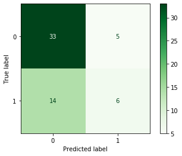

```python
from sklearn.metrics import confusion_matrix
from sklearn.metrics import classification_report
from sklearn.metrics import plot_confusion_matrix

# print accuracy report
print(classification_report(y_test_enc, y_predict, digits=3))

# show confusion matrix
plot_confusion_matrix(model, X_test_enc, y_test_enc,
                      #xticks_rotation='vertical',
                      cmap=plt.cm.Greens)
plt.show()
```

- the diagnol represents correct classification
- each row represents the instances of an actual class (true label) and each column represents the instances of a predicted class.
  - 5 were incorrectly classified as recurrence,
  - 14 incorrectly classified no-recurrence
- accuracy = correct classifications/total = (33+6)/(33+6 +19) = 67%
- proportion of predicted Positives is truly Positive: **precision** = TP/(TP+FP)
  - for recurrence: 6/(6 + 5)= 54.5%
  - Use if the costs of False Positive is high. Ex: spam detection, false positives where non-spam is identified as spam results in loss of important email. Here you want high precision.
- proportion of actual Positives correctly classified: **recall** = TP/(TP + FN)
  - for recurrence: 6/(6 + 14) = 30 %
  - Use when there is a high cost associated with False Negative. Ex. Cancer diagnosis. A patient with cancer (Actual Positive) is predicted as not having cancer (Predicted Negative). Here you want high recall.
- a single score that balances both precision and recall: **F-Measure** = 2(precision * recall)/(precision + recall)
  - for recurrence: 2 *(0.545* 0.300 )/(0.545 + 0.300 ) = 38.7 %

### Imabalanced Datasets

When a target distribution is highly imbalanced, Accuracy is not a great measure of performance. For example: spam detection. Generally, spam datasets are STRONGLY biased towards ham (eg: not-spam). If the data set is 90% ham, you would get high accuracy by saying every single email is ham.

**ROC curve (receiver operating characteristic curve)** is a plot that summarizes the performance of a binary classification model on the positive class. It's a popular diagnostic tool for classifiers on balanced and imbalanced binary prediction problems as it's not biased to the majority or minority class.

- is a plot of **False Positive Rate (x-axis)** vs **True Positive Rate (y-axis)** for a number of different candidate threshold values between 0.0 and 1.0. The true positive rate is referred to as the sensitivity or the recall.
  - x-axis: False Positive Rate=FP/(FP+TN)
  - y-axis: True Positive Rate=TP/(TP+FN)
- you may plot the ROC curve and choose a threshold that gives a desirable balance between the false positives and false negatives.

Ideally, we want the fraction of correct positive class predictions to be 1 (top of the plot) and the fraction of incorrect negative class predictions to be 0 (left of the plot).

- best possible classifier achieving perfect skill is the top-left at coordinate: (0,1)
- the threshold is applied to the probability cut-off point between the positive and negative classes (by default set at 0.5, halfway between each (0 and 1)

**ROC Curve of a Logistic Regression Model and a No Skill Classifier**

The ROC Curve for the Logistic Regression model is shown (orange dots). A no skill classifier as a diagonal line (blue dashes).

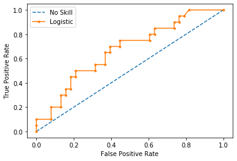

```python
from sklearn.metrics import roc_curve

yhat = model.predict_proba(X_test_enc) # predict only probability of 1.
pos_probs = yhat [:, 1] # probabilities for just the positive class

# plot no skill roc curve
pyplot.plot([0, 1], [0, 1], linestyle='--', label='No Skill')

fpr, tpr, _ = roc_curve(y_test_enc, pos_probs) # calculate roc curve for model

# plot model roc curve
pyplot.plot(fpr, tpr, marker='.', label='Logistic')
pyplot.xlabel('False Positive Rate')
pyplot.ylabel('True Positive Rate')
pyplot.legend()
pyplot.show()
```

**ROC Area Under Curve (AUC) Score**  
Although the ROC Curve is a helpful diagnostic tool, it can be challenging to compare two or more classifiers based on their curves. Instead, the area under the curve can be calculated for a single score for a classifier model across all threshold values. This is called the ROC area under curve or ROC AUC or sometimes ROCAUC.

- score is between 0.0 and 1.0 for a perfect classifier.
- can be used to compare binary classifier models directly and is commonly used for comparing classification models for imbalanced problems.
- the AUC for the ROC can be calculated using the roc_auc_score() function. It takes both the true outcomes (0,1) from the test set and the predicted probabilities for the positive class.

```python
from sklearn.dummy import DummyClassifier
from sklearn.metrics import roc_auc_score

# no skill model, stratified random class predictions
np.random.seed(1)
m = DummyClassifier(strategy='stratified')
m.fit(X_train_enc, y_train_enc)
no_skill_yhat = m.predict_proba(y_test_enc)
no_skill_roc_auc = roc_auc_score(y_test_enc, no_skill_yhat[:, 1])
print(f'No Skill ROC AUC {round(no_skill_roc_auc, 3)}')

# skilled model
roc_auc = roc_auc_score(y_test_enc, pos_probs)
print(f'Logistic ROC AUC {round(roc_auc, 3)}')
```

```
No Skill ROC AUC 0.43
Logistic ROC AUC 0.67
```

we can see that the ROC AUC for the Logistic Regression model (0.67) is better than a no skill classifier (0.43)

**Precision-recall curve and AUC(area under curve)**  
Though widely used, the ROC AUC is not without problems.

For imbalanced classification with a severe skew and few examples of the minority class, the ROC AUC can be misleading, because a small number of correct or incorrect predictions can result in a large change in the ROC Curve or ROC AUC score.

- an alternative is the **precision-recall curve and area under curve**

**Precision/Recall** are better performance metric when dealing with imbalanced classes.

- Precision is about exactness: classifying only one instance correctly yields 100% precision, but a very low recall. It tells how well the system identifies samples from a given class.
- Recall is about completeness: classifying all instances as positive yields 100% recall, but a very low precision. It tells how well the system does and identify all the samples from a given class.
- Both precision and the recall are focused on the positive(minority class) and are unconcerned with the true negatives (majority class).
- These two metrics are combined together in a metric called F1 (i.e., harmonic mean of precision and recall)

**A precision-recall curve (or PR Curve)** is a plot of the precision (y-axis) and the recall (x-axis) for different probability thresholds.

- a perfect skill model is depicted as a point at a coordinate of (1,1)
- no-skill classifier will be a horizontal line with a precision proportional to the number of positive examples. For a balanced dataset this will be 0.5.
- the focus of the PR curve on the minority class makes it an effective diagnostic for imbalanced binary classification models

A precision-recall curve can be calculated with **precision_recall_curve()**: takes the class labels and predicted probabilities for the minority class and returns the precision, recall, and thresholds

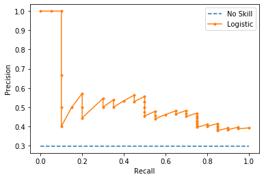

```python
from sklearn.metrics import precision_recall_curve

# calculate the no skill line as the proportion of the positive class
no_skill = len(y2[y2==1]) / len(y2)

# plot the no skill precision-recall curve
pyplot.plot([0, 1], [no_skill, no_skill], linestyle='--', label='No Skill')

# calculate model precision-recall curve
precision, recall, _ = precision_recall_curve(y_test_enc, pos_probs)

# plot the model precision-recall curve
pyplot.plot(recall, precision, marker='.', label='Logistic')
pyplot.xlabel('Recall')
pyplot.ylabel('Precision')
pyplot.legend()
pyplot.show()
```

**The Precision-Recall AUC**

- summarizes the curve with a range of threshold values as a single score.
- The score can then be used as a point of comparison between different models on a binary classification problem where a score of 1.0 represents a model with perfect skill.

```python
from sklearn.metrics import auc

# no skill model, stratified random class predictions
precision, recall, _ = precision_recall_curve( y_test_enc, no_skill_yhat[:, 1])
auc_score = auc(recall, precision)
print(f'No Skill PR AUC: {round(auc_score, 3)}')

# skilled model
precision, recall, _ = precision_recall_curve( y_test_enc, pos_probs)
auc_score = auc(recall, precision)
print(f'Logistic PR AUC: {round(auc_score, 3)}')
```

```
No Skill PR AUC: 0.329
Logistic PR AUC: 0.52
```

can see that the Precision-Recall AUC for the Logistic Regression model (0.52) is much better than a no skill classifier

**Balancing data for Imbalanced Classification**  
Imbalanced classification involves developing predictive models on classification datasets that have a severe class imbalance. The challenge is that most ML techniques will ignore, and in turn have poor performance on, the minority class, although typically it is performance on the minority class that is most important.

There are various approaches to handling unbalanced datasets. One approach is **Synthetic Minority Oversampling Technique (SMOTE)**.

Here new examples are synthesized from the existing examples. This is a type of data augmentation for the minority class referred to as the Synthetic Minority Oversampling Technique, or SMOTE for short.

```python
#!pip install imblearn
from imblearn.over_sampling import SMOTE

print('before balancing')
print(y2.value_counts() )

oversample = SMOTE()
X_train, y_train = oversample.fit_resample(X2, y2)

print ('\nafter balancing')
print(y_train.value_counts())
```

```
before balancing
0    201
1     85
Name: Class_recurrence-events, dtype: int64

after balancing
1    201
0    201
Name: Class_recurrence-events, dtype: int64
```

Once balanced, you can perform modeling as per usual

### Decision Tree

Decision tree is a systematic approach for multiclass classification. It poses a set of questions to the dataset (related to its attributes/features). The decision tree classification algorithm can be visualized on a binary tree. On the root and each of the internal nodes, a question is posed and the data on that node is further split into separate records that have different characteristics. The leaves of the tree refer to the classes in which the dataset is split.

We can use grid search for hyper parameter tuning. For decision treens, hyperparameters include:

- criterion (gini or entrop, default=gini)
- splitter (best or random, default=best)
- max_depth (default is None).
- In Scikit-learn, optimization of decision tree classifier performed pre-pruning. Maximum depth of the tree can be used as a control variable for pre-pruning

**Pima Indians Diabetes** This dataset is originally from the National Institute of Diabetes and Digestive and Kidney Diseases.

- The objective is to predict based on diagnostic measurements whether a patient has diabetes.
- label (ground-truth) column indicates whether this observation has diabetes (1) or not (0)

```python
col_names = ['pregnant', 'glucose', 'bp', 'skin', 'insulin', 'bmi', 'pedigree', 'age', 'label']

url = 'https://raw.githubusercontent.com/jbrownlee/Datasets/master/pima-indians-diabetes.data.csv'

pima = pd.read_csv(url, header=None, names=col_names)
pima.head()
```

|  | pregnant | glucose | bp | skin | insulin | bmi | pedigree | age | label |
| --- | --- | --- | --- | --- | --- | --- | --- | --- | --- |
| 0 | 6 | 148 | 72 | 35 | 0 | 33.6 | 0.627 | 50 | 1 |
| 1 | 1 | 85 | 66 | 29 | 0 | 26.6 | 0.351 | 31 | 0 |
| 2 | 8 | 183 | 64 | 0 | 0 | 23.3 | 0.672 | 32 | 1 |
| 3 | 1 | 89 | 66 | 23 | 94 | 28.1 | 0.167 | 21 | 0 |
| 4 | 0 | 137 | 40 | 35 | 168 | 43.1 | 2.288 | 33 | 1 |

```python
#split dataset in features and target variable
feature_cols = ['pregnant','glucose','bp', 'skin', 'insulin', 'bmi', 'pedigree', 'age']

X = pima[feature_cols] # Features
y = pima.label # Target variable
```

```python
# Split dataset into training set and test set 70% train, 30% test
X_train, X_test, y_train, y_test = train_test_split(X, y, test_size=0.3, random_state=1)
```

**Hyperparameter optimization** or tuning is the process of choosing a set of optimal hyperparameters for a learning algorithm. A hyperparameter is a parameter whose value is used to control the learning process.

GridSearchCV is part of sklearn's model_selection package. It's used to loop through a set of predefined hyperparameters and fist your model on your training set. In the end, you can select the best parameters from the listed hyperparameters.

- DecisionTreeClassifier requires 2 parameters 'criterion' and 'max_depth' to be optimised by GridSearchCV.

```python
from sklearn.tree import DecisionTreeClassifier
from sklearn.model_selection import GridSearchCV

def dtree_grid_search(X,y,nfolds):

    #create a dictionary of all values we want to test
    param_grid = { 'criterion':['gini','entropy'],'max_depth': np.arange(3, 15)}

    # decision tree model
    dtree_model=DecisionTreeClassifier()

    #use gridsearch to test all values
    dtree_gscv = GridSearchCV(dtree_model, param_grid, cv=nfolds)

    #fit model to data
    dtree_gscv.fit(X, y)

    return dtree_gscv.best_params_

dtree_grid_search(X_train, y_train, 3)
```

```
{'criterion': 'entropy', 'max_depth': 3}
```

from the GridSearch function, the optiminm tuning arguments are entropy with a max tree depath of 3.

```python
# classifier
dt_clf = DecisionTreeClassifier(random_state=0, criterion = "entropy", max_depth=3)

# train
dt_clf.fit(X_train, y_train)

# make predictions
y_predictions = dt_clf.predict(X_test)
```

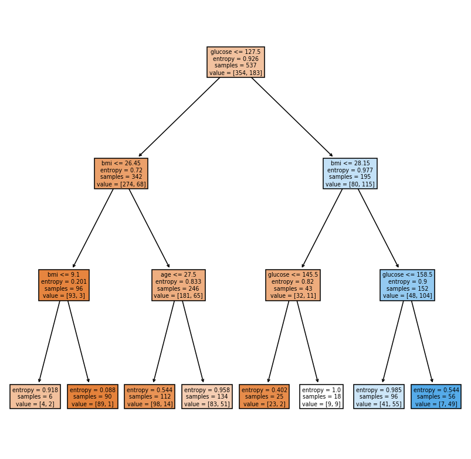

```python
from sklearn import tree

fig, axes = plt.subplots(figsize = (9,9), dpi=112)
tree.plot_tree(dt_clf,
               feature_names = feature_cols,
               filled = True)
plt.show()
```

```python
# determine most important features
importances = pd.DataFrame({'feature':X_train.columns,'importance':np.round(dt_clf.feature_importances_,3)})
importances = importances.sort_values('importance',ascending=False)
importances
```

|  | feature | importance |
| --- | --- | --- |
| 1 | glucose | 0.563 |
| 5 | bmi | 0.327 |
| 7 | age | 0.111 |
| 0 | pregnant | 0.000 |
| 2 | bp | 0.000 |
| 3 | skin | 0.000 |
| 4 | insulin | 0.000 |
| 6 | pedigree | 0.000 |

glucose has the highest feature importance, confirmed by looking at the corresponding decision tree.

**Check model performance**

```
              precision    recall  f1-score   support

           0      0.800     0.849     0.824       146
           1      0.711     0.635     0.671        85

    accuracy                          0.771       231
   macro avg      0.755     0.742     0.747       231
weighted avg      0.767     0.771     0.768       231
```

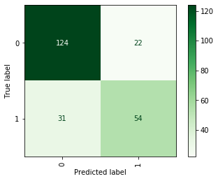

```python
# print accuracy report
print(classification_report(y_test, y_predictions, digits=3))

# show confusion matrix
plot_confusion_matrix(dt_clf, X_test, y_test,
                      xticks_rotation='vertical',
                      cmap=plt.cm.Greens)
plt.show()
```

```python
# Return the mean accuracy on the given test data and labels.
round(dt_clf.score(X_test, y_test), 4)
```

```
0.7706
```

### Unsupervised (KMEANS)

K-means is a unsupervised ML algorithm used for clustering unlabelled data into k clusters.

- The process begins with k centroids initialised at random.
- These centroids are used to assign points to its nearest cluster.
- The mean of all points within the cluster is then used to update the position of the centroids.
- The above steps are repeated until the values of the centroids stabilise.

To explore KMEANs, we will use the diabetes dataset without consideration of the label

```python
X
```

|  | pregnant | glucose | bp | skin | insulin | bmi | pedigree | age |
| --- | --- | --- | --- | --- | --- | --- | --- | --- |
| 0 | 6 | 148 | 72 | 35 | 0 | 33.6 | 0.627 | 50 |
| 1 | 1 | 85 | 66 | 29 | 0 | 26.6 | 0.351 | 31 |
| 2 | 8 | 183 | 64 | 0 | 0 | 23.3 | 0.672 | 32 |
| 3 | 1 | 89 | 66 | 23 | 94 | 28.1 | 0.167 | 21 |
| 4 | 0 | 137 | 40 | 35 | 168 | 43.1 | 2.288 | 33 |
| ... | ... | ... | ... | ... | ... | ... | ... | ... |
| 763 | 10 | 101 | 76 | 48 | 180 | 32.9 | 0.171 | 63 |
| 764 | 2 | 122 | 70 | 27 | 0 | 36.8 | 0.340 | 27 |
| 765 | 5 | 121 | 72 | 23 | 112 | 26.2 | 0.245 | 30 |
| 766 | 1 | 126 | 60 | 0 | 0 | 30.1 | 0.349 | 47 |
| 767 | 1 | 93 | 70 | 31 | 0 | 30.4 | 0.315 | 23 |

768 rows × 8 columns

**scale the features to give equal importance to all features**

```python
from sklearn.cluster import KMeans
from sklearn.preprocessing import StandardScaler

X = StandardScaler().fit_transform(X)
X
```

```
array([[ 0.63994726,  0.84832379,  0.14964075, ...,  0.20401277,
         0.46849198,  1.4259954 ],
       [-0.84488505, -1.12339636, -0.16054575, ..., -0.68442195,
        -0.36506078, -0.19067191],
       [ 1.23388019,  1.94372388, -0.26394125, ..., -1.10325546,
         0.60439732, -0.10558415],
       ...,
       [ 0.3429808 ,  0.00330087,  0.14964075, ..., -0.73518964,
        -0.68519336, -0.27575966],
       [-0.84488505,  0.1597866 , -0.47073225, ..., -0.24020459,
        -0.37110101,  1.17073215],
       [-0.84488505, -0.8730192 ,  0.04624525, ..., -0.20212881,
        -0.47378505, -0.87137393]])
```

**Attempt to find the optiminum value of K**

- **Elbow Method**: Inertia is the mean squared distance between each instance and its closest centroid. The lower the inertia better the model.

As k increases, the sum of squared distance tends to zero. If we set k to its maximum value n (where n is number of samples) each sample will form its own cluster meaning sum of squared distances equals zero. If the plot looks like an arm, then the elbow on the arm is optimal k.

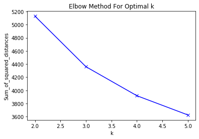

```python
Sum_of_squared_distances = []
K = range(2,6)
for k in K:
    km = KMeans(n_clusters=k, random_state=1).fit(X)
    Sum_of_squared_distances.append(km.inertia_)

plt.plot(K, Sum_of_squared_distances, 'bx-')
plt.xlabel('k')
plt.ylabel('Sum_of_squared_distances')
plt.title('Elbow Method For Optimal k')
plt.show()
```

- In this case, the elbow is not very obvious, but looks to be at around 3

**Silhouette Score**: is a better measure to decide the number of clusters. The coefficient varies between -1 and 1, where

- 1: clusters are well apart from each other and clearly distinguished.
- 0: clusters are indifferent, or we can say that the distance between clusters is not significant.
- -1: clusters are assigned in the wrong way.

```
For k = 2 The average silhouette_score is : 0.1949
For k = 3 The average silhouette_score is : 0.1795
For k = 4 The average silhouette_score is : 0.2017
For k = 5 The average silhouette_score is : 0.166
```

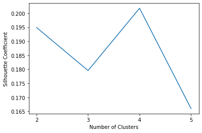

```python
from sklearn.metrics import silhouette_score

silhouette_coefficients = []

for k in K:
    clusterer = KMeans(n_clusters=k, random_state=1)
    cluster_labels = clusterer.fit_predict(X)

    silhouette_avg = silhouette_score(X, cluster_labels)
    print("For k =", k, "The average silhouette_score is :", round(silhouette_avg, 4))
    silhouette_coefficients.append(silhouette_avg)


plt.plot(K, silhouette_coefficients)
plt.xticks(K)
plt.xlabel("Number of Clusters")
plt.ylabel("Silhouette Coefficient")
plt.show()
```

- k = 2 or 4 has the highest score
- we know that 2 is the correct value

Next split the dataset for train and test

```python
# train/test split 80/20
X_train, X_test, y_train, y_test = train_test_split(X, y, test_size=0.2, random_state=1)
```

```python
k_means = KMeans(n_clusters=2, random_state=1)

# fit on training set
k_means.fit(X_train)

# predict on test
y_predict = k_means.predict(X_test)

print('cluster centers\n', k_means.cluster_centers_)
print('cluster labels\n', k_means.labels_)
```

```
cluster centers
 [[ 0.93031447  0.37719743  0.40698066 -0.28066016 -0.11453252  0.05842229
  -0.01394849  1.03610441]
 [-0.52806993 -0.20025126 -0.25530281  0.09148262  0.05578041 -0.06587823
  -0.03045647 -0.5916124 ]]
cluster labels
 [0 0 0 0 1 1 0 1 1 1 0 0 1 0 0 0 0 0 1 1 1 0 0 1 1 0 0 1 1 0 1 0 0 1 1 1 0
 1 1 1 1 1 0 1 1 0 0 0 1 1 0 0 1 0 1 0 1 1 0 0 1 0 0 1 1 1 1 1 1 1 1 1 1 1
 1 0 0 0 1 1 1 1 1 0 0 0 1 0 1 0 1 1 0 1 1 1 1 1 1 0 1 0 1 1 0 0 0 1 1 1 1
 1 1 1 1 0 0 0 1 1 0 0 1 0 0 0 1 1 1 0 1 1 0 0 1 0 1 0 1 0 1 1 1 1 1 0 0 1
 1 1 1 1 1 0 1 1 0 1 0 1 0 1 1 1 1 0 0 0 1 1 1 1 0 0 0 0 1 1 0 0 0 0 1 1 0
 1 1 1 1 1 1 0 0 1 0 1 0 1 1 0 0 1 1 1 1 1 0 1 1 0 1 1 0 0 1 1 1 1 1 1 1 1
 1 1 1 1 1 0 1 0 0 1 0 1 1 1 1 0 1 0 1 1 1 1 1 0 1 0 1 1 1 1 1 0 1 1 1 1 1
 1 1 1 1 0 1 0 1 0 1 1 0 1 1 0 1 1 1 1 0 1 0 1 0 1 1 0 0 0 1 0 0 1 0 1 1 1
 0 0 1 1 1 0 1 1 1 1 0 0 1 1 0 1 1 1 1 1 1 0 0 1 0 1 1 1 1 0 1 0 1 1 1 1 0
 0 0 1 0 1 1 0 1 1 0 1 1 0 1 1 0 0 0 1 1 1 0 0 1 1 1 1 1 1 0 0 1 0 0 1 1 0
 1 1 0 1 1 1 0 1 1 1 1 0 1 1 1 0 1 1 1 1 0 1 0 1 1 1 1 1 1 1 1 1 1 1 1 0 0
 1 0 1 0 0 1 0 1 0 1 1 1 1 1 1 1 0 1 0 1 1 1 0 1 1 0 0 1 1 1 1 1 1 1 1 1 0
 0 0 0 0 1 0 0 1 0 1 1 1 1 1 0 0 0 0 1 0 1 0 1 0 0 1 0 1 1 1 1 0 0 1 0 0 1
 1 0 0 1 1 1 1 1 1 0 0 1 0 1 1 0 0 1 1 0 1 0 1 1 1 1 1 0 0 1 1 1 1 1 0 1 1
 1 1 1 1 1 1 0 1 1 1 1 0 1 1 1 1 1 1 1 0 1 1 0 0 1 1 1 1 0 0 1 0 1 1 0 1 0
 1 1 1 1 1 0 0 0 1 1 1 1 1 0 1 0 0 1 1 1 1 1 1 0 1 1 1 1 0 1 1 0 0 0 0 0 1
 1 1 0 1 1 1 0 0 1 0 0 1 1 0 0 0 1 1 0 0 0 0]
```

**plot clusters**

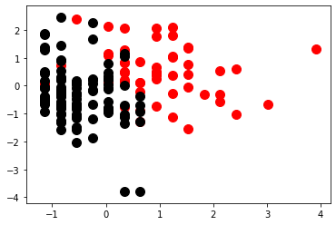

```python
plt.scatter(X_test[y_predict ==0,0], X_test[y_predict == 0,1], s=100, c='red');
plt.scatter(X_test[y_predict ==1,0], X_test[y_predict == 1,1], s=100, c='black');
```

### Clustering performance evaluation

- https://scikit-learn.org/stable/modules/clustering.html#clustering-performance-evaluation

Evaluating the performance of a clustering algorithm is not as trivial as counting the number of errors or the precision and recall of a supervised classification algorithm. In particular any evaluation metric should not take the absolute values of the cluster labels into account but rather if this clustering define separations of the data similar to some ground truth set of classes or satisfying some assumption such that members belong to the same class are more similar than members of different classes according to some similarity metric.

### Given ground truth labels

**Rand index** Rand index is a function that measures the similarity between true and predicted labels.

- Values range between -1 and 1. A score close to 0 indicates random assignments. A score close to 1 indicates perfectly labeled clusters.

```python
from sklearn.metrics.cluster import adjusted_rand_score

adjusted_rand_score(y_test, y_predict)
```

```
0.1496478873239437
```

**Homogeneity** metric of a cluster labeling given a ground truth. A clustering result satisfies homogeneity if all of its clusters contain only data points which are members of a single class.

- score between 0.0 and 1.0. 1.0 stands for perfectly homogeneous labeling

```python
from sklearn.metrics.cluster import homogeneity_score
homogeneity_score(y_test, y_predict)
```

```
0.08704144347713873
```

### No ground truth labels

Usually in unsupervised ML, ground truth labels are not available. If the ground truth labels are not known, evaluation must be performed using the model itself.

**Silhouette Coefficient** is an example of such an evaluation, where a higher Silhouette Coefficient score relates to a model with better defined clusters.

```python
kmeans_model = KMeans(n_clusters=2, random_state=1).fit(X_train)
labels = kmeans_model.labels_
silhouette_score(X_train, labels, metric='euclidean')
```

```
0.1929860851350856
```

**Davies-Bouldin index** can be used to evaluate the model. This index signifies the average ‘similarity’ between clusters, where the similarity is a measure that compares the distance between clusters with the size of the clusters themselves.

- lower Davies-Bouldin index relates to a model with better separation between the clusters.
- 0 is the lowest possible score. Values closer to zero indicate a better partition.

```python
from sklearn.metrics import davies_bouldin_score
davies_bouldin_score(X_train, labels)
```

```
2.014049043046679
```